# R - Introducing getting, testing and plotting data

This is an R Notebook using [R Markdown](http://rmarkdown.rstudio.com).

For novices, using this Notebook will be much more understandable if you have worked through the lesson “Introducing R, R Studio and R Notebooks.” Also, this Notebook should be read and used in tandem with “R - Introducing variables and summary statistics”

In this Notebook, we’re going to do some work getting a classic data set, doing some familiar statistical tests, more summary statistics, and some plotting. This lesson is also reliant on resources at NIMBioS (www.nimbios.org)

After you have worked through this and its companion R Notebook, you should be ready to explore two tools in Digital Natural History: BIEN (for plants) and GBIF (for all organisms). Both of those explorations will blend browser-based work and using R and R Studio with R Notebooks.

# GETTING DATA

Let’s download some data. Francis Galton, one of the founders of statistics, also promoted the science of eugenics. (For a long and wonderful feminist discussion about eugenics, see the book Ghost Stories for Darwin by Banu Subramanian). Galton was also the cousin of Charles Darwin. Galton invented the term “regression”. These days, “regression” means fitting the best-fit line to a series of x and y data points. But, why is the weird term “regression” used for this? What is regressing?

Let’s look at Galton’s original dataset: the heights of parents and children.

Use your web browser to [navigate here](http://www.randomservices.org/random/data/Galton.html)

…and save Galton.txt (right-click, save) to your working directory.

After doing this, double-click on Galton.txt and view the file, just to see what’s in there.

Come back to R Studio when you’re done.

We will double-check that your data file is in the working directory.

(We cheated … it’s already there from your GitHub cloning!)

```r
getwd()
list.files()
```

Let’s store the filename in a variable

Note: In your head, eventually:

“wd” will mean “working directory” “fn” will mean “filename”

```r
#wd = "C:/Users/hcallaha/Desktop/Callahan/Data"
#setwd(wd)
fn = "Galton.txt"
heights = read.table(fn, header=TRUE, sep="\t")
#And, look at "heights"
heights
fn <- read.table("Galton.txt", header=TRUE, sep="\t")
```

[output not shown]

Close the output from the chunk above.

Then edit the chunk above.

“Comment out” lines to be sure it won’t run as a command. For heights, add a # in front of it Also add a line as follows: head(heights)

And, while we’re at it, let’s get three other pieces of information

#### Column names

names(heights)

#### Dimensions (rows, columns)

dim(heights)

#### Class (data.frame, matrix, character, numeric, list, etc.)

class(heights)

Add those three lines into the chunk above, then run the chunk.

Now let’s look at some summary statistics:

```r
#Means
#colMeans(heights)

colMeans(heights[,c(-1,-4)])

# Standard deviations
apply(X=heights[,c(-1,-4)], MARGIN=2, FUN=sd)

# Min & Max
apply(X=heights[,c(-1,-4)], MARGIN=2, FUN=min)
apply(X=heights[,c(-1,-4)], MARGIN=2, FUN=max)
```

You cannot get the chunk to run because the colMeans function will not operate on non-numeric variables, in this case the “Family” variable in column 1 and the “Gender” variable in column 4.

Comment out that very first line (line 83) by adding “#” at the front of the line. Then remove the “#” from line 85.

What line 85 is asking for is to use the same dataframe, but to skip the first column and the fourth column.

Then run the chunk again.

Here, “Height” refers to the kids’ heights.

# TESTING DATA

```r
# Make sure variable columns are numeric
heights$Family = as.numeric(heights$Family)
heights$Father = as.numeric(heights$Father)
heights$Height = as.numeric(heights$Height)
heights$Kids = as.numeric(heights$Kids)

# Let's add the Midparent column
heights[,c("Father","Mother")]

# Take the mean of Father and Mother columns, then store it in a new column in the dataframe called "Midparent"
heights$Midparent = apply(X=heights[,c("Father","Mother")], MARGIN=1, FUN=mean)

# View the new column
head(heights)

# Population Mean Between Two Independent Samples:
# http://www.r-tutor.com/elementary-statistics/inference-about-two-populations/population-mean-between-two-independent-samples

# (change "Child" to "Height")
ttest_result1 = t.test(x=heights$Midparent, y=heights$Height, paired=FALSE, alternative="two.sided")
ttest_result1
```

But wait, this test assumes that the samples from each population are independent. Do you think parent heights and child heights are independent?

Probably not. Actually, these samples are paired, so let’s check that:

Population Mean Between Two Matched Samples: http://www.r-tutor.com/elementary-statistics/inference-about-two-populations/population-mean-between-two-matched-samples

```r
ttest_result2 = t.test(x=heights$Midparent, y=heights$Height, paired=TRUE, alternative="two.sided")
ttest_result2

# Compare the two:
ttest_result1
ttest_result2

# Interestingly, it looks like parents are slightly taller than the children!

# Is this statistically significant?

# But is it a large effect?  Is it *practically* significant?
```

[output not shown]

# PLOTTING DATA

```r
# Let's plot the histograms
library(lattice)
hist(heights$Midparent)
hist(heights$Height)
```

That’s a little hard to compare, due to the different automated scaling of the x-axis.

All the code below is *not* in chunks

You can also run code in an R Notebook by highlighting line(s) and pressing the “Run” icon below, or by pressing Control+Enter. But, the code will show up in the Console window (below). If you want the output to be incorporated into your R Notebook, then put the code into a chunk and then run the chunk. Output will not only appear in this window, but will also be saved into an accompanying notebook html file if you save your work before exiting.

Another option shown below is how to make the plots (which will show up in the Plots window, lower right) and then how to save the plot in PDF format when you’re happy with it.

```r
# Let's fix the x-axis to be (5 feet, 7 feet)
xlims = c(5*12, 7*12)

hist(heights$Midparent, xlim=xlims)
hist(heights$Height, xlim=xlims)

# Let's fix the y-axis to be (0, 220)
ylims = c(0, 220)
hist(heights$Midparent, xlim=xlims, ylim=ylims)
hist(heights$Height, xlim=xlims, ylim=ylims)

# Let's plot the means and 95% confidence intervals on top

# Midparent values
hist(heights$Midparent, xlim=xlims, ylim=ylims)

# Plot the mean
abline(v=mean(heights$Midparent), lty="dashed", lwd=2, col="blue")

# Plot the 95% confidence interval (2.5% - 97.5%)
CI_025 = mean(heights$Midparent) - 1.96*sd(heights$Midparent)
CI_975 = mean(heights$Midparent) + 1.96*sd(heights$Midparent)
abline(v=CI_025, lty="dotted", lwd=2, col="blue")
abline(v=CI_975, lty="dotted", lwd=2, col="blue")

# Child values
hist(heights$Height, xlim=xlims, ylim=ylims)

# Plot the mean
abline(v=mean(heights$Height), lty="dashed", lwd=2, col="blue")

# Plot the 95% confidence interval (2.5% - 97.5%)
CI_025 = mean(heights$Height) - 1.96*sd(heights$Height)
CI_975 = mean(heights$Height) + 1.96*sd(heights$Height)
abline(v=CI_025, lty="dotted", lwd=2, col="blue")
abline(v=CI_975, lty="dotted", lwd=2, col="blue")

# Let's put the plot into nice PDF format to save it

# Open a PDF for writing
pdffn = "Galton_height_histograms_v1.pdf"
pdf(file=pdffn, width=8, height=10)

# Do 2 subplots
par(mfrow=c(2,1))

# Midparent values
hist(heights$Midparent, xlim=xlims, ylim=ylims, xlab="height (inches)", ylab="Count", main="Midparent heights")

# Plot the mean
abline(v=mean(heights$Midparent), lty="dashed", lwd=2, col="blue")

# Plot the 95% confidence interval (2.5% - 97.5%)
CI_025 = mean(heights$Midparent) - 1.96*sd(heights$Midparent)
CI_975 = mean(heights$Midparent) + 1.96*sd(heights$Midparent)
abline(v=CI_025, lty="dotted", lwd=2, col="blue")
abline(v=CI_975, lty="dotted", lwd=2, col="blue")

# Child values
hist(heights$Height, xlim=xlims, ylim=ylims, xlab="height (inches)", ylab="Count", main="Child heights")

# Plot the mean
abline(v=mean(heights$Height), lty="dashed", lwd=2, col="blue")

# Plot the 95% confidence interval (2.5% - 97.5%)
CI_025 = mean(heights$Height) - 1.96*sd(heights$Height)
CI_975 = mean(heights$Height) + 1.96*sd(heights$Height)
abline(v=CI_025, lty="dotted", lwd=2, col="blue")
abline(v=CI_975, lty="dotted", lwd=2, col="blue")

# Close the PDF writing
dev.off()

# Write a system command as a text string
cmdstr = paste("open ", pdffn, sep="")
cmdstr

# Send the command to the computer system's Terminal/Command Line
system(cmdstr)

# The PDF should hopefully pop up, e.g. if you have the free Adobe Reader
```

### This is a VERY IMPORTANT lesson: “statistically significant” DOES NOT ALWAYS MEAN “practically”significant“,”interesting“,”scientifically relevant“, etc.

The difference may have to do with:

- Galton’s ‘method’ of dealing with the fact that male and female children have different average heights – he multiplied the female heights by 1.08!
- Different nutrition between the generations
- Maybe the adult children weren’t quite all fully grown
- Chance rejection of the null

Who knows?

You may have noticed that the standard deviations look to be a lot different. Can we test for this?

```r
# Yes! The null hypothesis is that the ratio of the variances is 1:

Ftest_result = var.test(x=heights$Midparent, y=heights$Height, ratio=1, alternative="two.sided")
Ftest_result
```

[output not shown]

For the complex story of Galton’s original data, see: http://www.medicine.mcgill.ca/epidemiology/hanley/galton/

#### [James A. Hanley (2004). ‘Transmuting’ women into men: Galton’s family data on human stature. The American Statistician, 58(3) 237-243.](http://www.medicine.mcgill.ca/epidemiology/hanley/reprints/hanley_article_galton_data.pdf)

BTW, Galton was both a genius, and promoted some deeply flawed ideas like [eugenics](http://isteve.blogspot.com/2013/01/regression-toward-mean-and-francis.html).

We noted before that child and parent heights might not be independent. Let’s test this!

QUESTION: is there a relationship?

Start by plotting the data:

```r
plot(x=heights$Midparent, y=heights$Height)

# It looks like there is a positive relationship: taller parents have taller children.

# However, it's a little bit hard to tell for sure, because Galton's data is only measured to the half-inch, so many dots are plotting on top of each other.  We can fix this by "jittering" the data:

# Plot the data, with a little jitter
plot(x=jitter(heights$Midparent), y=jitter(heights$Height))
```

[output not shown]

```r
# Let's build a linear model (lm)
lm_result = lm(formula=Height~Midparent, data=heights)
lm_result

# This just has the coefficients; this doesn't tell us much.

# What's in the linear model? A list of items:
names(lm_result)

# See the statistical results
summary(lm_result)

# Analysis of variance (ANOVA)
anova(lm_result)
```

```r
# Let's plot the regression line on top of the points
intercept_value = lm_result$coefficients["(Intercept)"]
slope_value = lm_result$coefficients["Midparent"]


# Plot the points
plot(x=jitter(heights$Midparent), y=jitter(heights$Height))

# Add the line

abline(a=intercept_value, b=slope_value, col="blue", lwd=2, lty="dashed")

# It's a little hard to tell if the slope is 1:1 or not, because the x-axis and y-axis aren't the same. Let's fix this.

# Plot the points
xlims = c(5*12, 6.5*12)
ylims = c(5*12, 6.5*12)
plot(x=jitter(heights$Midparent, factor=3), y=jitter(heights$Height, factor=3), xlab="Midparent height", ylab="Child height", xlim=xlims, ylim=ylims)
title("Galton's height data")

# Add the regression line
abline(a=intercept_value, b=slope_value, col="blue", lwd=2, lty="dashed")

# Add the 1:1 line
abline(a=0, b=1, col="darkgreen", lwd=2, lty="dashed")
```

Is the slope statistically different from 1:1?

```r
# We can test this by subtracting a 1:1 relationship from the data, and seeing if the result has a slope different from 0
child_minus_1to1 = heights$Height - (1/1*heights$Midparent)
heights2 = heights
heights2 = cbind(heights2, child_minus_1to1)
```

```r
# Let's build a linear model (lm)
lm_result2 = lm(formula=child_minus_1to1~Midparent, data=heights2)
lm_result2

# This just has the coefficients; this doesn't tell us much
# What's in the linear model? A list of items:
names(lm_result2)

# See the statistical results
summary(lm_result2)

# Analysis of variance (ANOVA)
anova(lm_result2)
```

```r
# You can get some standard diagnostic regression plots with:
plot(lm_result2)

# Let's plot the regression line on top of the points
intercept_value = lm_result2$coefficients["(Intercept)"]
slope_value = lm_result2$coefficients["Midparent"]
```

```r
# Plot the points

plot(x=jitter(heights2$Midparent), y=jitter(heights2$child_minus_1to1), xlim=xlims, xlab="Midparent heights", ylab="Child heights minus 1:1 line", main="Relationship after subtracting 1:1 line")

# Add the regression line
abline(a=intercept_value, b=slope_value, col="blue", lwd=2, lty="dashed")

# Add the expected line if the relationship was 1:1
abline(a=0, b=0, col="darkgreen", lwd=2, lty="dashed")
```

[output not shown]

Why is the relationship between parent height and offspring height LESS THAN 1:1???

Why do tall parents tend to produce offspring shorter than themselves? Why does height seem to “regress”? What about the children of short parents? Do they ‘regress’?

What are possible statistical consequences/hazards of this?

### Why is all of this rarely explained when regression is taught?

```r
#install.packages("BIEN")
library("BIEN")
library(ape) #Package for working with phylogenies in R
library(maps) #Useful for making quick maps of occurrences
library(sp) # A package for spatial data
#vignette("BIEN")
```

BIEN

```r
# Download the data for a focal species.
Castanea_dentata <- BIEN_occurrence_species(species = "Castanea dentata")
```

```r
str(Castanea_dentata)
```

```
'data.frame':   7822 obs. of  10 variables:
 $ scrubbed_species_binomial  : chr  "Castanea dentata" "Castanea dentata" "Castanea dentata" "Castanea dentata" ...
 $ latitude                   : num  38.2 35.5 39 41 39.9 ...
 $ longitude                  : num  -79.2 -81.6 -78.7 -74.6 -79.4 ...
 $ date_collected             : Date, format: NA ...
 $ datasource                 : chr  "traits" "FIA" "FIA" "FIA" ...
 $ dataset                    : chr  "traits" "U.S. Forest Inventory and Analysis (FIA) National Program" "U.S. Forest Inventory and Analysis (FIA) National Program" "U.S. Forest Inventory and Analysis (FIA) National Program" ...
 $ dataowner                  : chr  "traits" "Greg Reams" "Greg Reams" "Greg Reams" ...
 $ custodial_institution_codes: chr  NA NA NA NA ...
 $ collection_code            : chr  NA NA NA NA ...
 $ datasource_id              : num  NA 65 65 65 NA 48 NA 23 65 65 ...
```

```r
head(Castanea_dentata)
```

|  | scrubbed_species_binomial | latitude | longitude | date_collected | datasource | dataset | dataowner | custodial_institution_codes | collection_code | datasource_id |
| --- | --- | --- | --- | --- | --- | --- | --- | --- | --- | --- |
| 1 | Castanea dentata | 38.19000 | -79.25000 |  | traits | traits | traits | NA | NA | NA |
| 2 | Castanea dentata | 35.54832 | -81.55657 | 2009-12-15 | FIA | U.S. Forest Inventory and Analysis (FIA) National Program | Greg Reams | NA | NA | 65 |
| 3 | Castanea dentata | 38.99454 | -78.65181 | 2010-03-09 | FIA | U.S. Forest Inventory and Analysis (FIA) National Program | Greg Reams | NA | NA | 65 |
| 4 | Castanea dentata | 40.97593 | -74.56442 | 2010-10-14 | FIA | U.S. Forest Inventory and Analysis (FIA) National Program | Greg Reams | NA | NA | 65 |
| 5 | Castanea dentata | 39.88759 | -79.44896 |  | traits | traits | traits | NA | NA | NA |
| 6 | Castanea dentata | 35.40000 | -83.10000 | 2003-06-11 | CVS | Carolina Vegetation Survey | Robert Peet | NA | NA | 48 |

```r
tail(Castanea_dentata)
```

|  | scrubbed_species_binomial | latitude | longitude | date_collected | datasource | dataset | dataowner | custodial_institution_codes | collection_code | datasource_id |
| --- | --- | --- | --- | --- | --- | --- | --- | --- | --- | --- |
| 7817 | Castanea dentata | 34.86329 | -84.62720 | 1999-09-09 | CVS | Carolina Vegetation Survey | Robert Peet | NA | NA | 48 |
| 7818 | Castanea dentata | 34.64416 | -84.20369 | 2000-07-21 | CVS | Carolina Vegetation Survey | Robert Peet | NA | NA | 48 |
| 7819 | Castanea dentata | 34.12341 | -87.29098 | 1999-10-04 | CVS | Carolina Vegetation Survey | Robert Peet | NA | NA | 48 |
| 7820 | Castanea dentata | 34.96681 | -83.30000 | 2000-07-19 | CVS | Carolina Vegetation Survey | Robert Peet | NA | NA | 48 |
| 7821 | Castanea dentata | 34.86681 | -84.64813 | 1999-09-09 | CVS | Carolina Vegetation Survey | Robert Peet | NA | NA | 48 |
| 7822 | Castanea dentata | 34.91238 | -84.64117 | 1999-09-09 | CVS | Carolina Vegetation Survey | Robert Peet | NA | NA | 48 |

```r
chestnut_rangemap <- BIEN_ranges_load_species("Castanea dentata")
```

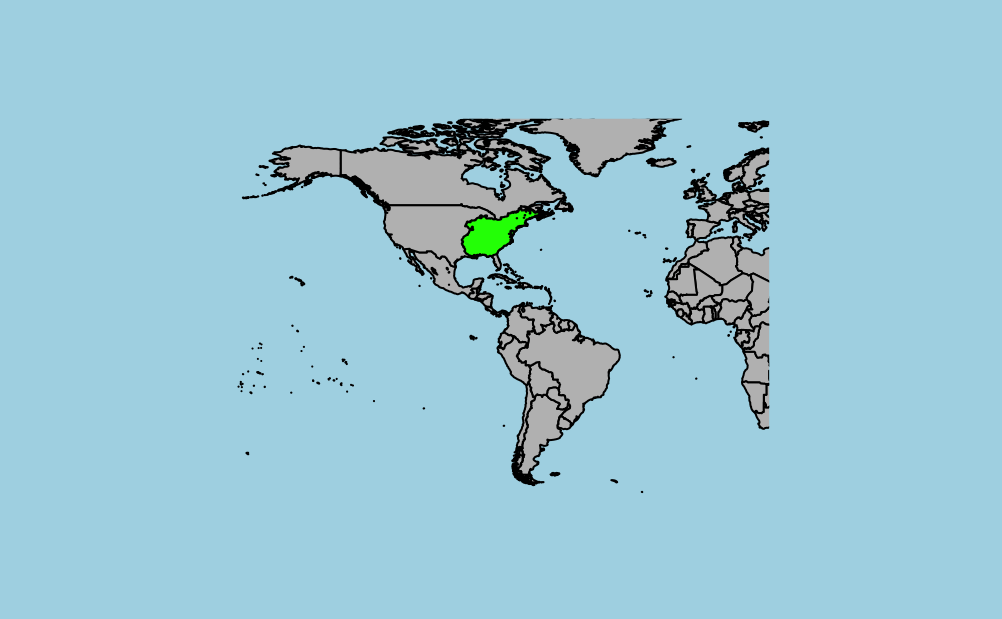

```r
# Map the range of chestnut
map('world', fill=T, col="grey", bg = "light blue", xlim=c(-180,20),ylim=c(-60,80))
plot(chestnut_rangemap, col="green", add=T)
```

```r
# Map the range of chestnut + occurence records
map('world', fill=T, col="grey", bg="light blue", xlim=c(-180,-20), ylim=c(-60, 80))
plot(chestnut_rangemap, col="green", add=T)
```

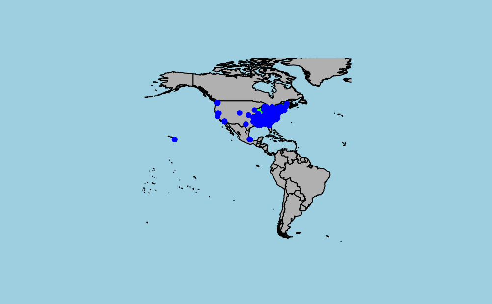

```r
points(cbind(Castanea_dentata$longitude, Castanea_dentata$latitude), col="blue", pch=20, cex=1)
```

```r
Castanea_dentata_full <- BIEN_occurrence_species(species = "Castanea dentata",cultivated = T,only.new.world = F,all.taxonomy = T,native.status = T,observation.type = T,political.boundaries = T)
str(Castanea_dentata_full)
```

```
'data.frame':   7949 obs. of  34 variables:
 $ scrubbed_species_binomial   : chr  "Castanea dentata" "Castanea dentata" "Castanea dentata" "Castanea dentata" ...
 $ verbatim_family             : chr  "Fagaceae" "Fagaceae" "Fagaceae" "Fagaceae" ...
 $ verbatim_scientific_name    : chr  "Castanea dentata (Marsh.) Borkh." "Castanea dentata (Marsh.) Borkh." "Castanea dentata (Marsh.) Borkh." "Castanea dentata (Marsh.) Borkh." ...
 $ family_matched              : chr  "Fagaceae" "Fagaceae" "Fagaceae" "Fagaceae" ...
 $ name_matched                : chr  "Castanea dentata" "Castanea dentata" "Castanea dentata" "Castanea dentata" ...
 $ name_matched_author         : chr  "(Marshall) Borkh." "(Marshall) Borkh." "(Marshall) Borkh." "(Marshall) Borkh." ...
 $ higher_plant_group          : chr  "flowering plants" "flowering plants" "flowering plants" "flowering plants" ...
 $ scrubbed_taxonomic_status   : chr  "Accepted" "Accepted" "Accepted" "Accepted" ...
 $ scrubbed_family             : chr  "Fagaceae" "Fagaceae" "Fagaceae" "Fagaceae" ...
 $ scrubbed_author             : chr  "(Marshall) Borkh." "(Marshall) Borkh." "(Marshall) Borkh." "(Marshall) Borkh." ...
 $ native_status               : chr  "P" "P" "P" "P" ...
 $ native_status_reason        : chr  "Present in one or more checklists for region, status not indicated" "Present in one or more checklists for region, status not indicated" "Present in one or more checklists for region, status not indicated" "Present in one or more checklists for region, status n…
 $ native_status_sources       : chr  "usda" "usda" "usda" "usda" ...
 $ is_introduced               : int  0 0 0 0 0 0 0 0 0 0 ...
```

[output cut: 20 more lines]

```r
map('world', fill=T , col="grey", bg="light blue")
#Plot the points from the full query in red
points(cbind(Castanea_dentata_full$longitude, Castanea_dentata_full$latitude), col="red", pch=20, cex=1)
```

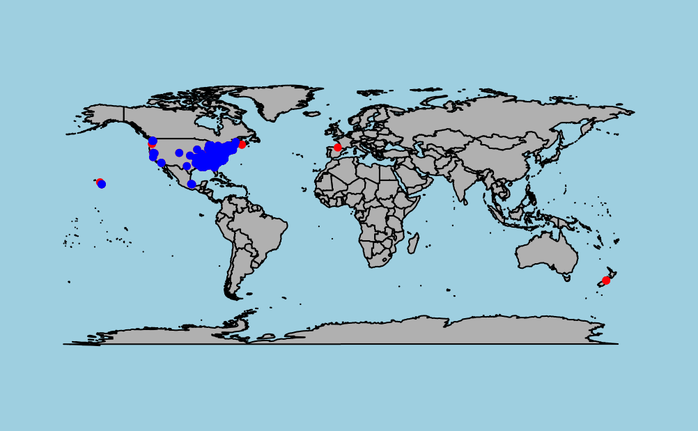

```r
# Plot the points from the default query in blue
points(cbind(Castanea_dentata$longitude, Castanea_dentata$latitude), col="blue", pch=20, cex=1)
```